# **Project - Classification and Hypothesis Testing: Hotel Booking Cancellation Prediction**

#### **Question 6.5: What are some important features based on the tuned decision tree? (1 Mark)**

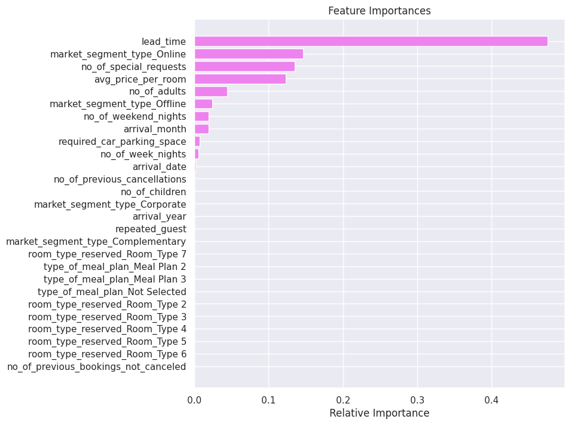

```python
# Remove _________ and complete the code

# Importance of features in the tree building

importances = estimator.feature_importances_
indices = np.argsort(importances)

plt.figure(figsize=(8, 8))
plt.title("Feature Importances")
plt.barh(range(len(indices)), importances[indices], color="violet", align="center")
plt.yticks(range(len(indices)), [feature_names[i] for i in indices])
plt.xlabel("Relative Importance")
plt.show()
```

We can simplify our models by focusing on the one with the highest relative importance. The top 5 features:

1. `lead_time`
2. `market_segment_type_Online`
3. `no_of_special_requests`
4. `avg_price_per_room`
5. `no_of_adults`

### **Question 7: Random Forest (4 Marks)**

#### **Question 7.1: Build a Random Forest Model (1 Mark)**

```python
# Remove _________ and complete the code

rf_estimator = RandomForestClassifier()

rf_estimator.fit(X_train_scaled, y_train)
```

```
RandomForestClassifier()
```

#### **Question 7.2: Check the performance of the model on the train and test data (2 Marks)**

```
              precision    recall  f1-score   support

           0       0.99      1.00      1.00     17073
           1       1.00      0.99      0.99      8319

    accuracy                           0.99     25392
   macro avg       0.99      0.99      0.99     25392
weighted avg       0.99      0.99      0.99     25392
```

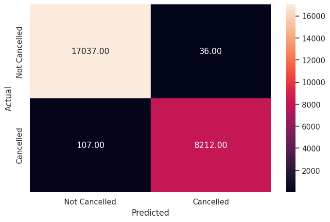

```python
# Remove _________ and complete the code

y_pred_train_rf = rf_estimator.predict(X_train_scaled)

metrics_score(y_train, y_pred_train_rf)
```

This operates similar to the original DT. Is it overfit?

```
              precision    recall  f1-score   support

           0       0.91      0.95      0.93      7317
           1       0.89      0.80      0.84      3566

    accuracy                           0.90     10883
   macro avg       0.90      0.88      0.88     10883
weighted avg       0.90      0.90      0.90     10883
```

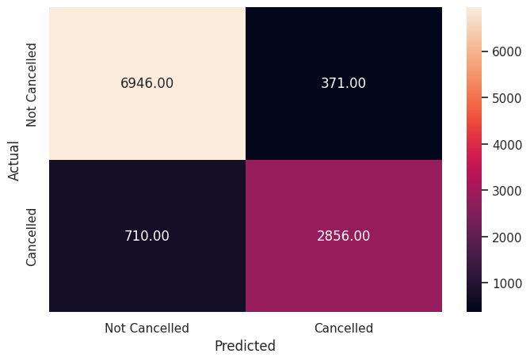

```python
# Remove _________ and complete the code

y_pred_test_rf = rf_estimator.predict(X_test_scaled)

metrics_score(y_test, y_pred_test_rf)
```

Wow! Really good F1 score and the errors are low relative to other models.

#### **Question 7.3: What are some important features based on the Random Forest? (1 Mark)**

Let's check the feature importance of the Random Forest

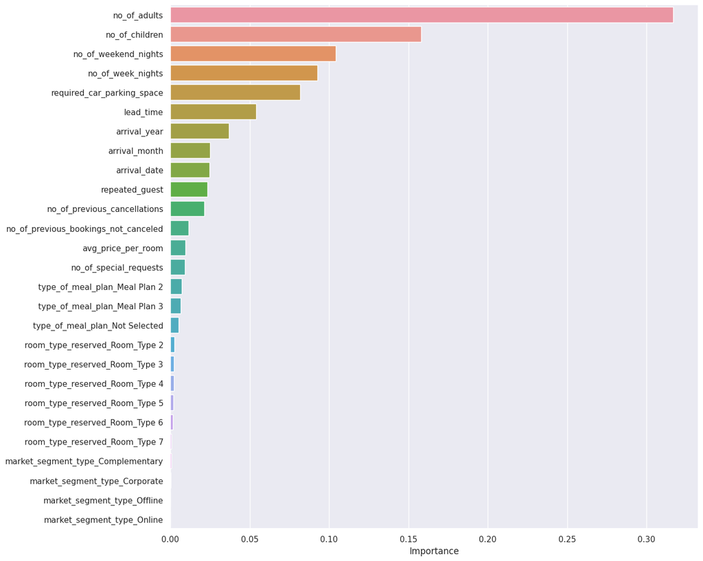

```python
# Remove _________ and complete the code

importances_rf = rf_estimator.feature_importances_

columns = X.columns

importance_df = pd.DataFrame(importances_rf, columns=['Importance'], index=columns)

plt.figure(figsize = (13, 13))

sns.barplot(x=importance_df.Importance.sort_values(ascending=False), y=importance_df.index)
```

### **Question 8: Conclude ANY FOUR key takeaways for business recommendations (4 Marks)**

#### **Classifiers are a tradeoff between speed and accuracy of results.**

The LogisticRegression classifier was fast making its use ideal in production but the recall was low and we had to do post processing to "fix it up" with marginal results. The SVM classifer was *slow* and didn't yield much better results. The Decision Tree was fast and performed better than both but it requires configuration. The same for the Random Forest which performed the best but requires lots of tuning. If the pre-work for tuning can be done in a reasonable time as business conditions change, the Random Forest is the best choice.